# White Wines

We can also have a 2D visualization of the plot:

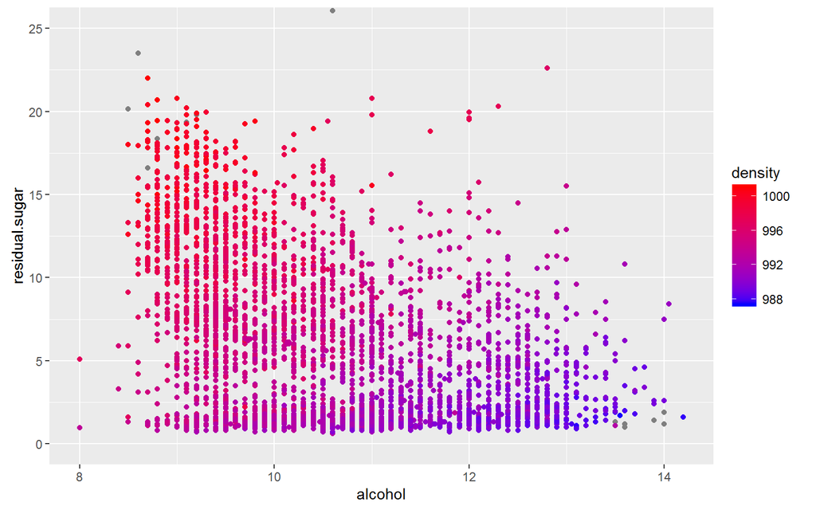

Notice there is graddient along the high `alcohol` low `residual.sugar` (blue) to low `alcohol` high `residual.sugar` (red). This is related to the slope of the fitting plane on the previous 3D plot.

- acidity

For the acidity correlations subgroup:

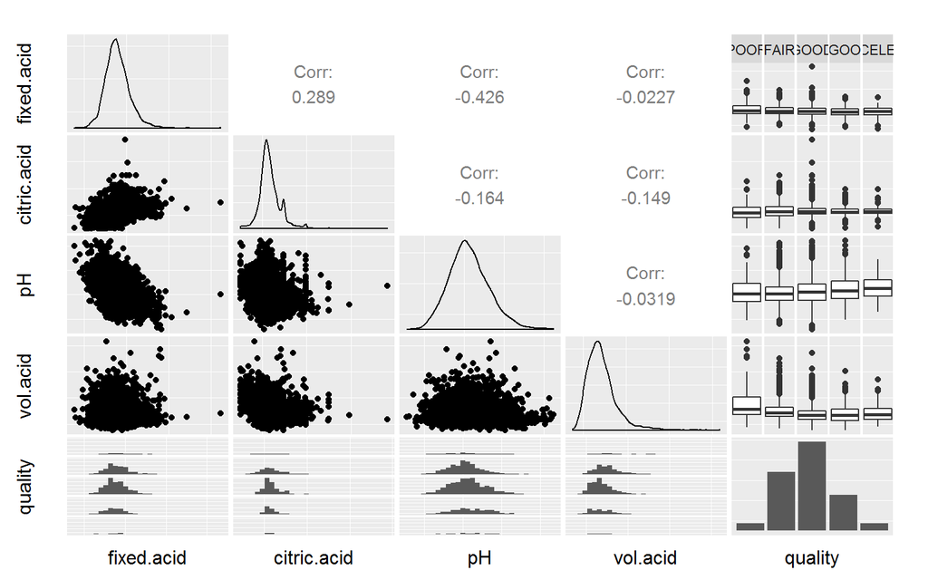

Numbers are smaller and trends are less visible than in the density case. Largest (negative) correlation is between `fixed.acidity` and `pH`.

Inspired in the density success, I look for a similar relation for acidity. pH is defined as the logarithm of hidrogen eletrolites in the solution. So $exp(pH) \sim fixed.acidity + citric.acid$ can be a good call:

```
##
## Call:
## lm(formula = exp(ww$pH) ~ ww$citric.acid + ww$fixed.acidity,
##     data = ww)
##
## Residuals:
##     Min      1Q  Median      3Q     Max
## -8.1762 -2.3019 -0.4944  1.7787 19.7865
##
## Coefficients:
##                  Estimate Std. Error t value Pr(>|t|)
## (Intercept)      37.63921    0.41171  91.421  < 2e-16 ***
## ww$citric.acid   -1.31477    0.43363  -3.032  0.00244 **
## ww$fixed.acidity -1.84817    0.06219 -29.720  < 2e-16 ***
## ---
## Signif. codes:  0 '***' 0.001 '**' 0.01 '*' 0.05 '.' 0.1 ' ' 1
##
## Residual standard error: 3.515 on 4895 degrees of freedom
## Multiple R-squared:  0.1739, Adjusted R-squared:  0.1736
## F-statistic: 515.4 on 2 and 4895 DF,  p-value: < 2.2e-16
```

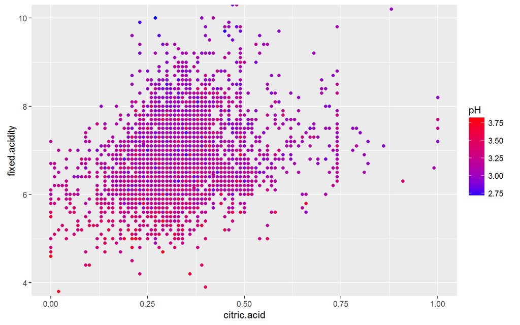

Adjusted R-Squared is 0.1736, which is much lower than expected. One can see the pattern that lower `fixed.acidity` wines usually have higher `pH` on the plot, but, again, is not as evident as it should be.

- sulphates

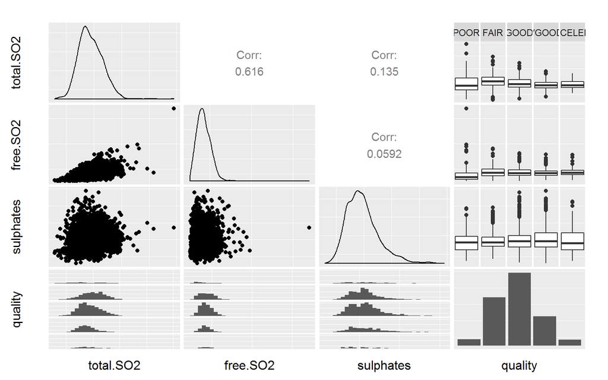

Correlation between `total.sulphur.dioxide` and `free.sulphur.dioxide` is quite high, but boxplots show that this correlation doesn’t relate to quality behavior. This is because the later is related to antioxidant agents that prevent wine from spoilage, while the first is about not having enough SO2 so it can affect the taste of the wine.

### Developing insights about largest trend (alcohol, density)

Let’s go back to the `residual.sugar` vs. `alcohol plot`

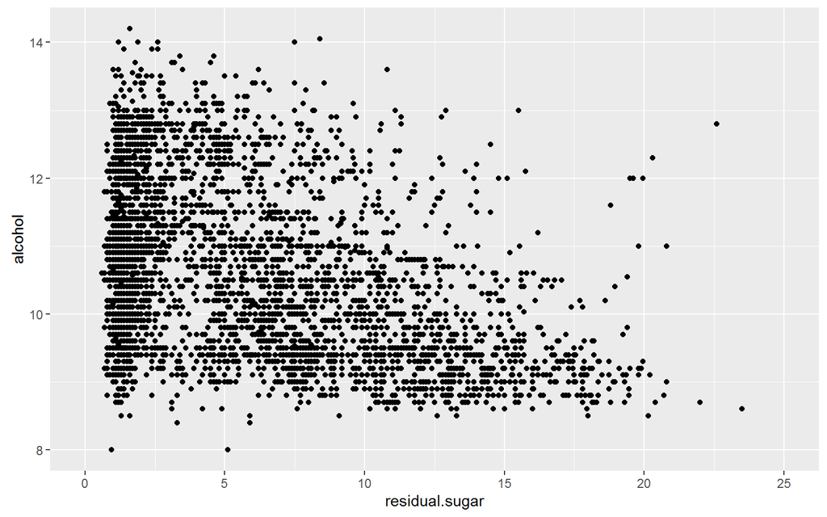

The plot shows that aren’t many high alcohol/high sugar wines (in the right upper quadrant). Except to that, correlation is not very clear. Googling around, I found that these variables are related to the initial sugar content of the grape juice, as alcohol is the product of fermentation of a percentage of this inicial sugar. So the triangular shape has the meaning that most sweet wines in this dataset had their fermentation process interrupted too early. It also says that few initial grape juice had more than a certain amount of initial sugar = residual sugar + alcohol * constant, where this constant is defined by the fermentation process and, sparing the reader from unit manipulation details of winemaking, a good guess is 1.66. Before going into new variables, lets colour the plot with quality.

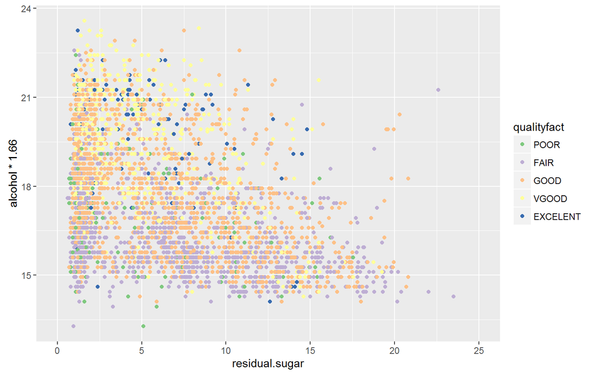

As expected, quality improves with alcohol (y axis), but the role of the residual sugar is not clear. Let’s make a variable change. instead of alcohol and residual sugar, let’s use as new variables:
$$sugar.juice = residual.sugar + alcohol *1.66$$
and
$$fermented.percentual = \frac{must.weight - residual sugar}{must.weight}$$

```
##    Min. 1st Qu.  Median    Mean 3rd Qu.    Max.
##   14.23   20.13   23.33   23.85   26.91   85.22
```

```
##    Min. 1st Qu.  Median    Mean 3rd Qu.    Max.
##  0.2279  0.6294  0.7719  0.7572  0.9134  0.9670
```

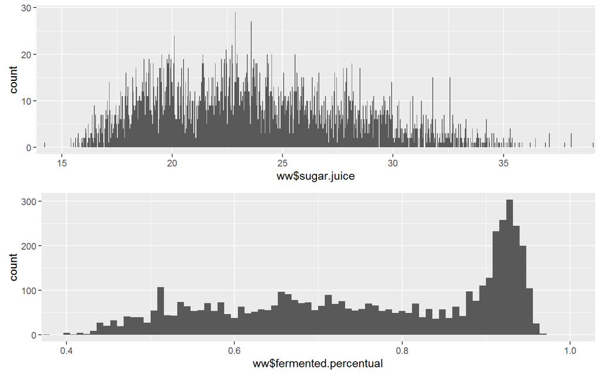

Now let’s make the analogous of residual.sugar, alcohol, quality plot for the new variables:

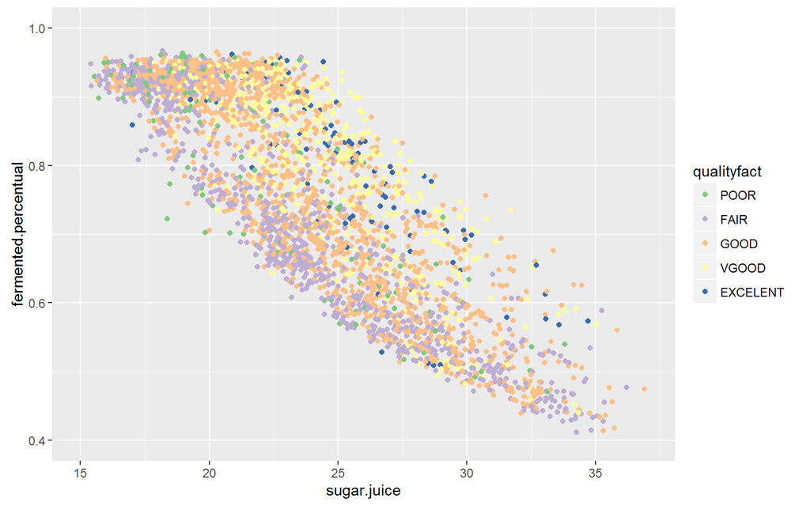

OK, that’s pretty good! This plot summarizes that largest trend seen between alcohol and quality, including the residual.sugar variable information, giving it a more meaningfull interpretation: the quality of the wine can be described by a combination of high sugar on grape juice and high fermentation percentual. There is a curvature on the trend. Let’s try a log scale.

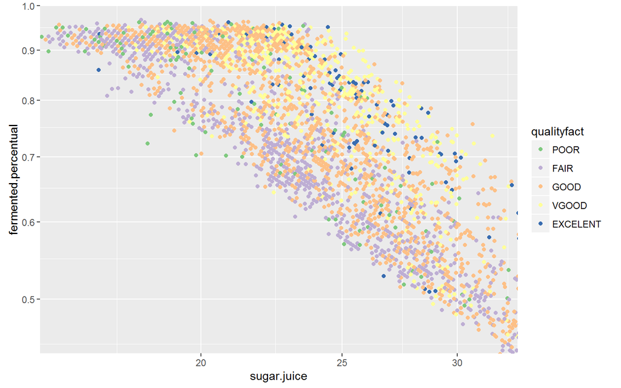

Great, as we get an almost linear gradient for quality. Let’s colour this with pH now, to see if we can connect these findings with acidity:

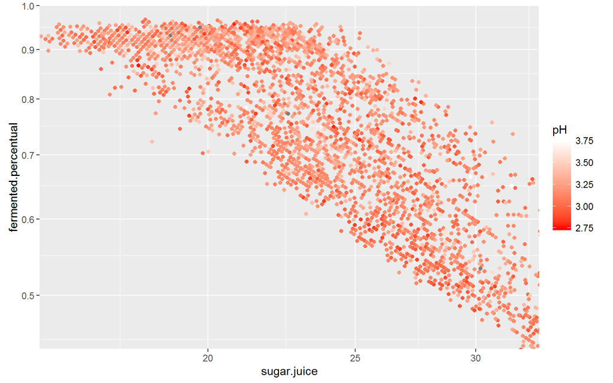

The pattern is lost here.

### Distance model

Back to the quality colouring, the distance from the base of the trapezoid and any point should be a great probe for quality:

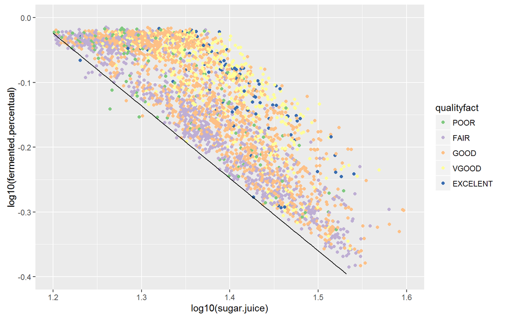

Black line formula is $y + 1.12x - 1.32 = 0$. Next I calculate the perpendicular distance form each point to this line and compare the alcohol quality trend with the new variable trend in boxplots:

```
##     Min.  1st Qu.   Median     Mean  3rd Qu.     Max.
## -0.03891  0.02745  0.05002  0.05553  0.07759  0.15180
```

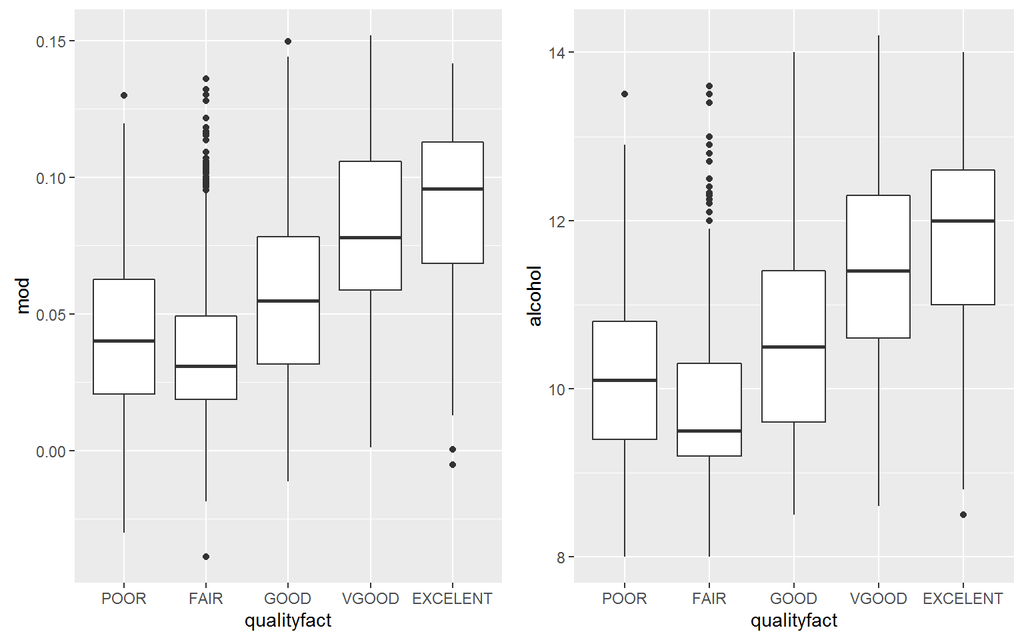

The above defined distance quantity (left) explains the quality of wine similary to alcohol (right), but with the interpretation that fermentation.percentage and must.weight should be high together, which is more useful.

Taking this into account we subset data for good wines (distance > median(0.05))

```
## [1] 2264    9
```

```
##  fixed.acidity    volatile.acidity  citric.acid           pH
##  Min.   : 3.800   Min.   :0.0800   Min.   :0.0000   Min.   :2.740
##  1st Qu.: 6.200   1st Qu.:0.2100   1st Qu.:0.2800   1st Qu.:3.090
##  Median : 6.750   Median :0.2600   Median :0.3200   Median :3.190
##  Mean   : 6.767   Mean   :0.2782   Mean   :0.3278   Mean   :3.198
##  3rd Qu.: 7.300   3rd Qu.:0.3200   3rd Qu.:0.3700   3rd Qu.:3.290
##  Max.   :14.200   Max.   :1.1000   Max.   :1.6600   Max.   :3.820
##  free.sulfur.dioxide total.sulfur.dioxide   sulphates         quality
##  Min.   :0.00200     Min.   :0.0090       Min.   :0.2200   Min.   :3.00
##  1st Qu.:0.02200     1st Qu.:0.0970       1st Qu.:0.3900   1st Qu.:6.00
##  Median :0.03100     Median :0.1180       Median :0.4600   Median :6.00
##  Mean   :0.03189     Mean   :0.1210       Mean   :0.4857   Mean   :6.25
##  3rd Qu.:0.04000     3rd Qu.:0.1420       3rd Qu.:0.5600   3rd Qu.:7.00
##  Max.   :0.14650     Max.   :0.3665       Max.   :1.0800   Max.   :9.00
##    qualityfact
##  POOR    :  56
##  FAIR    : 298
##  GOOD    :1081
##  VGOOD   : 677
##  EXCELENT: 152
##
```

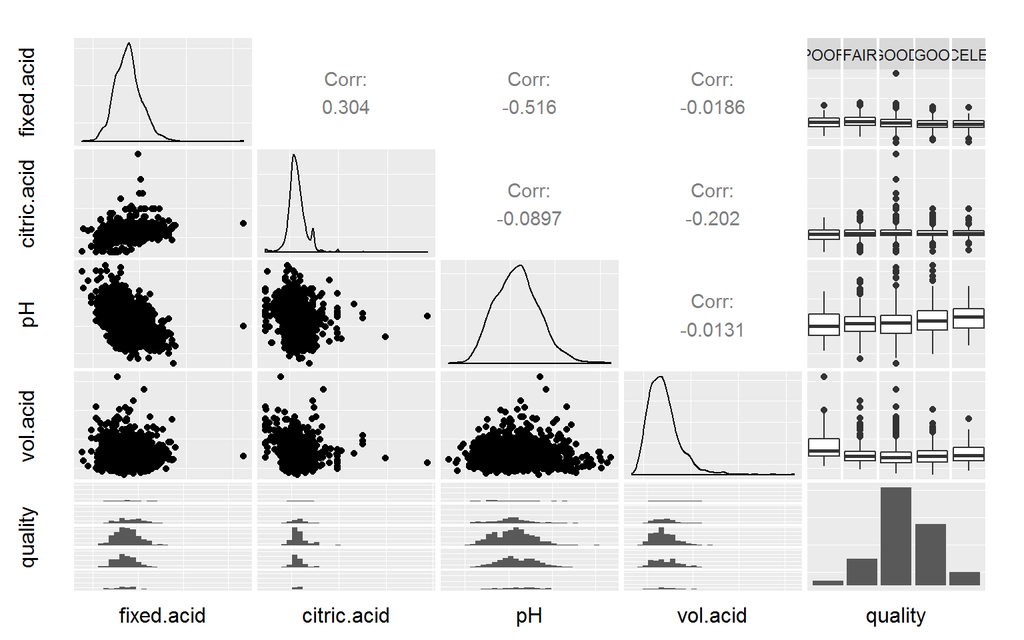

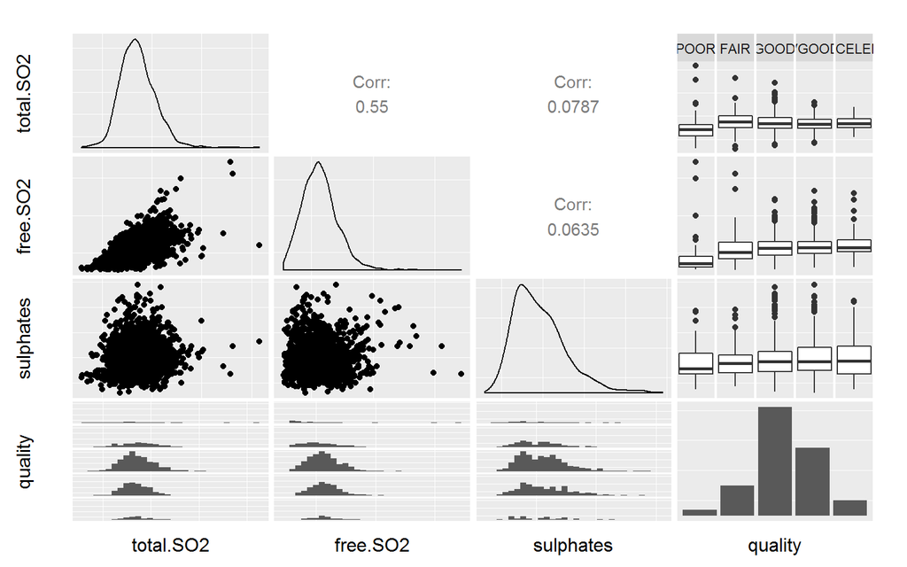

Ok, comparing with previous correlation plots, things didn’t seem to change very much. Correlation between `pH` and `fixed.acidity` improved from 0.42 to 0.51 and between total and free SO2 actually decreased from 0.61 to 0.55.

Let’s take a closer look at quality pH by comparing boxplots:

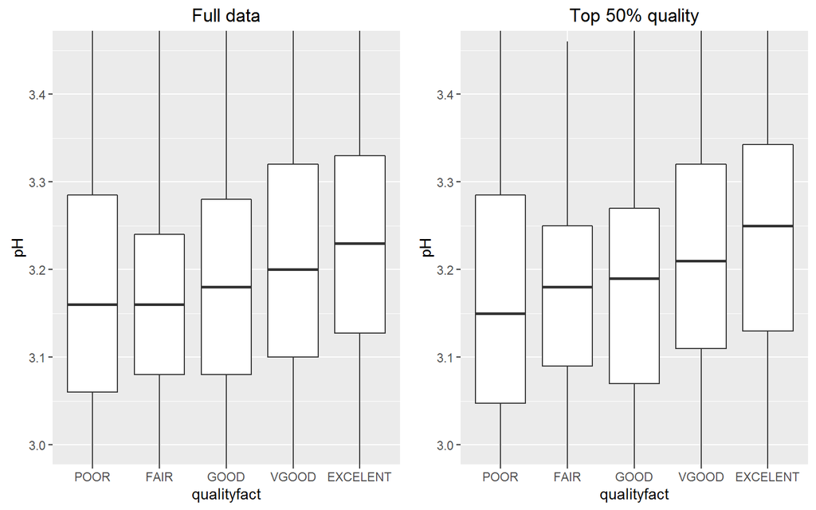

Left is complete data and right is 50% better quality data. Same trend for both sets.

Let’s check free SO2 part:

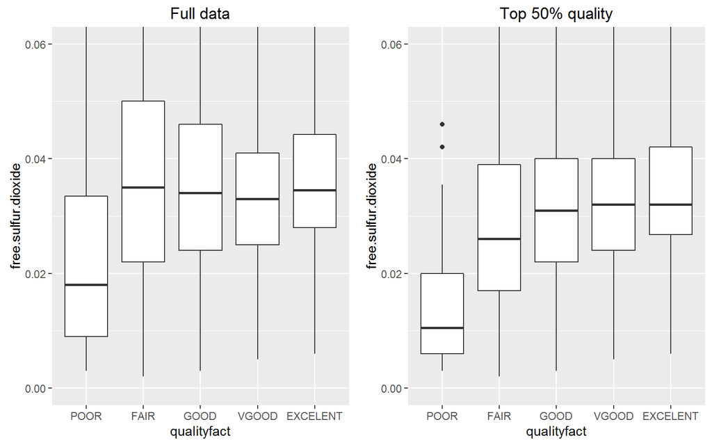

Well, that’s pretty cool. We already knew that POOR wine were related to low `free.sulphur oxide`, but on this better quality wines the trend is much smoother. This means that if the wines are good enough in the density aspect, its quality can be judged by it’s SO2 content.

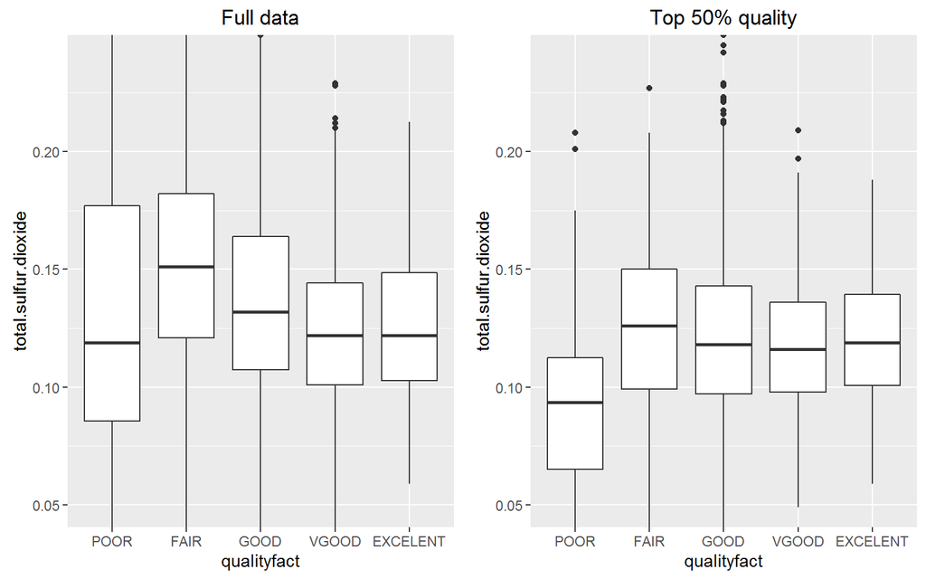

Finally let’s look at citric acid comparison.

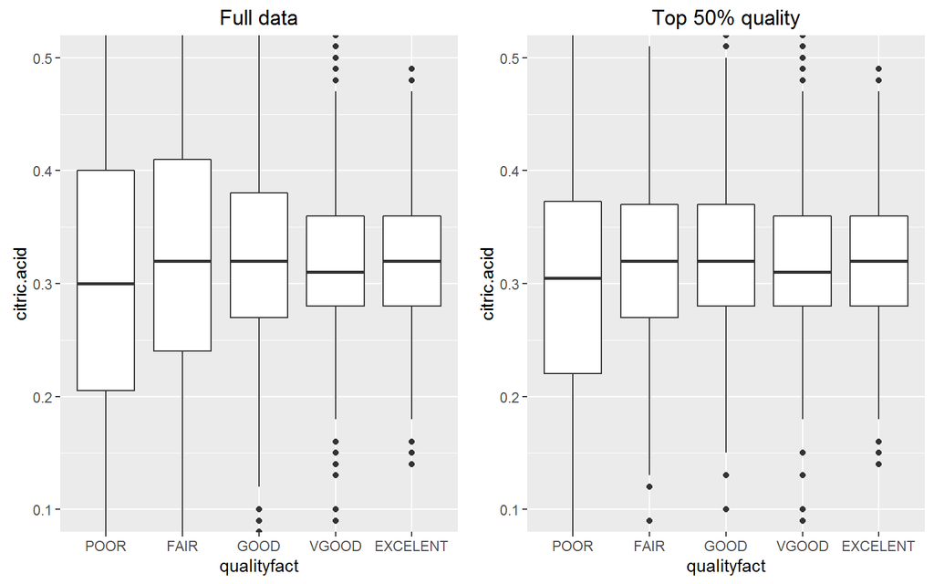

Nothing new here.

## Final Summary

Following the lead of the quality dependence with alcohol and density seen before, I’ve built a simple linear model that explains density variable as a weighted sum of alcohol and residual sugar (R squared 0.90). This opened the possibility to understand those big trends with quality by looking at alcohol and residual sugar variables only. Furthermore, the explanation that better wine is mostly about how much alcohol it has should be somehow improved and the role of residual sugar was unclear.

By making a coordinate transformation from `alcohol` and `residual sugar` to `sugar juice` and `fermented percentage` I was able to produce a plot that summarize the big trend and tell a more reasonable story: according to this data (and a few other suppositions), it is more probable to end up with a better quality wine if one starts with sweeter grape juice and certifies that it goes through a long enough fermentation process.

Trying to put this statement in a more quantitative base, I made a log10 rescale on both axis, which produced a more linear gradient behavior of quality along the `sugar juice` vs. `fermentation percentage` plane. The gradient is then measured as the geometric distance from a reference line, resulting in a variable that has a behavior with quality very similar to alcohol, but now including density and residual.sugar in the analysis.

Finally I subset the dataset on top half gradient.distance value and checked the quality trends of all variables left. It happened that all the trends were pretty much the same, except for free.sulphur.oxide, where it was significantly smoother.

Apart from things above that worked better, there were many things that didn’t work out. The most important example is acidity part of data, where trends were not well understood, resisting many tries of redefining ratio variables and plotting with `fixed.acidity` and `pH` and other variables.

# Final Plots

### Plot 1

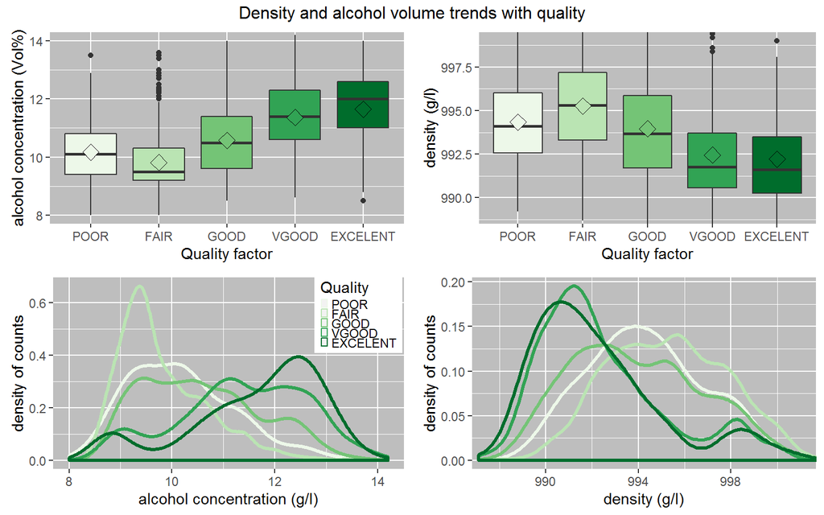

The above plots shows two aspects (boxplots and density plots) of the largest trends found from input variables with quality: alcohol(left) and density(right). We also plot the means for each quality as losangles. Both trends show that bad wines are most likely to have low alcohol concentration and high density, while the oposite is true for better quality wines.

### Plot 2

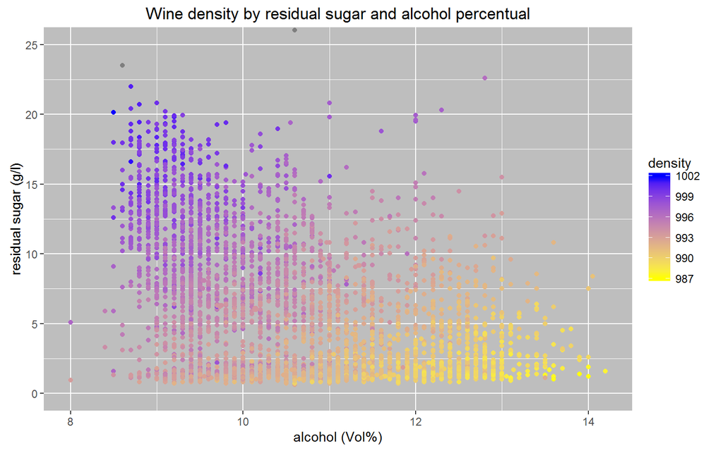

Residual sugar and alcohol are connected to density variable linearly, with adjusted R square statistics of 0.90 for the fit. High residual sugar and low alcohol implies high density (blue), while low residual sugar and high alcohol implies low density (yellow).

### Plot 3

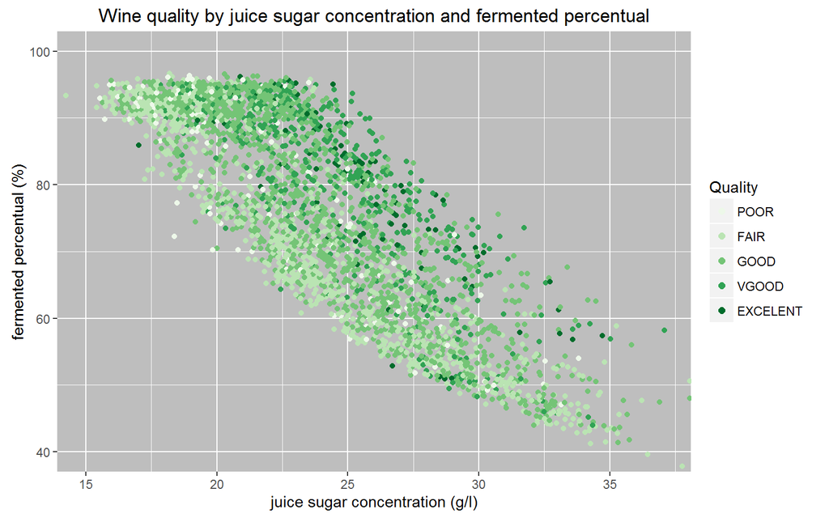

Sugar and alcohol were transformed into two new variables: the amount of sugar in the original grape juice and fermented percentual of the sugar. It happens that the original trend in alcohol and density can be sumarized in this plot. It shows that to make good wines one needs grape juice that is sweet enough and a fermentation process that is complete enough. For example, starting with a juice sugar concentration of 30 g/l we are looking a fermentation percentage of 70%, while 50% fermentation would probably produce a worse quality wine.

# Reflections

A seemingly inofensive dataset produced a very challenging task. The hardest part is contexting data. There is an overwhelming amount of information about wine, of the size of an area of human knowledge. How people make wine? What is quality? How are the experiments, and what exactly they measure? Those are some of the questions that I had to face before even knowing where to start, and one can dig as far as academic papers to extract this information. I didn’t go there and I set a specific goal: look for the largest trend and give some usefull advice to an imaginary wine producer. I think I’d achieved it: sweeter grapes and large fermentation percentual of sugar would be more likely to produce quality wines. As a bonus, I could say that wine is more likely to spoil on concentrations lower than about $0.035 \frac{g}{dm^3}$ of sulphur dioxide.

For the many limitation of this analysis, first there is the subjective aspect of the output variable quality. Dataset description says that quality is a score calculated from some items, so knowing those items could give us more insights about which aspect correspond to each chemical. Overall, would be much more interesting to have the price as output variable (continous), and check if price and quality are correlated. Another limitation is the depth of analysis on acidity, which seems to be the second most important variable. There are many dead ends not shown in this report pursuing this direction, among them ratios between some variable and acidity that could have given us some pattern to quality. At last, the analysis does not give the deserved atention to outliers by focusing on the median value. Those outliers could hide some information about good wines that don’t belong to the standard gradient pattern for example.